# Prosper Loan Data Exploration

## by Roger McClain

## Investigation Overview

> For this Data Exploration I will be taking a look at the Prosper Loan Data set, which contains data about 113,937 loans with 81 variables for each of them. This includes things like loan amount, interest rate, current loan status, borrower income, etc.

## Dataset Overview

> This dataset is structered in 81 columns by 113937 rows. This dataset is all variable related to Loans.

## Loan Status

> Here we can see the relative outcomes for all the loans. As we can clearly see, the vast majority of outcomes seem to be successful, with "Current" and "Completed" taking up the lions share. This does seem to suggest that the Prosper company has some way to determine whether or not a loan will be successful.

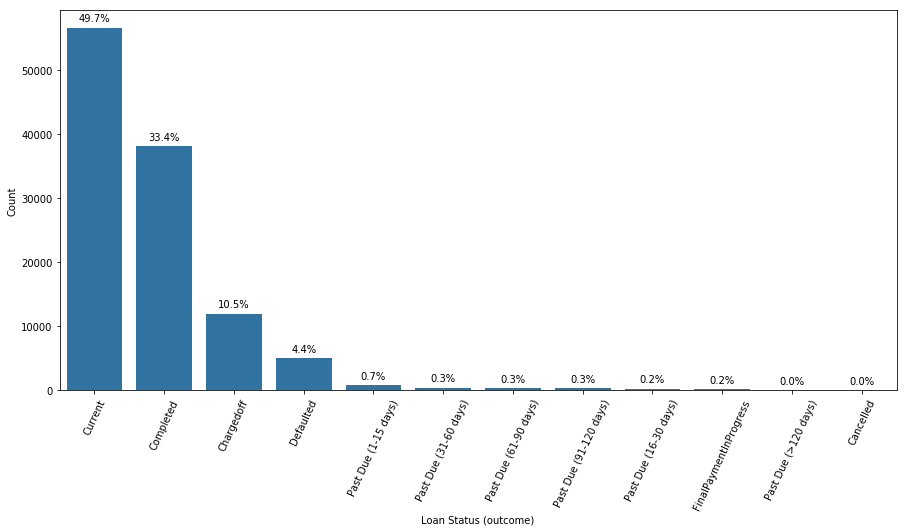

```python
# create the plot
plt.figure(figsize = [15, 7])
plt.xticks(rotation = 65)
base_color = sb.color_palette()[0]
cat_order = df['LoanStatus'].value_counts().index
sb.countplot(data = df, x = 'LoanStatus', color = base_color, order = cat_order)
plt.xlabel('Loan Status (outcome)')
plt.ylabel('Count')

# add annotations
n_points = df.shape[0]
cat_counts = df['LoanStatus'].value_counts()
locs, labels = plt.xticks() # get the current tick locations and labels

# loop through each pair of locations and labels
for loc, label in zip(locs, labels):

    # get text property for the label to get the correct count
    count = cat_counts[label.get_text()]
    pct_string = '{:0.1f}%'.format(100*count/n_points)

    # print annotation just above top of the bar
    plt.text(loc, count+1000, pct_string, ha = 'center', color = 'black')
```

## Loan Status outcomes vs Loan Original Amount

> The original graph of the Loan's Original Amount was heavily skewed to the right, but after a logarithmic transformation, we can see it has a multimodal distribution. We then use a facetgrid to compare it to the various loan status outcomes vs the Loan Original Amount. We can see in the graph that the distribution of all categories is multimodal, suggesting that there are certain "standard" amounts that loans are given out for e.g. (3000 dollars vs 2890 dollars).

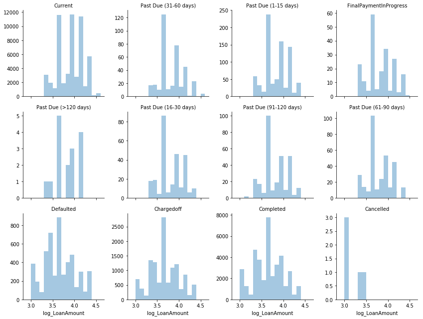

```python
df['log_LoanAmount'] = np.log10(df['LoanOriginalAmount'])
group_means = df.groupby(['LoanStatus']).mean()
group_order = group_means.sort_values(['LoanOriginalAmount'], ascending = False).index
g = sb.FacetGrid(data = df, col = 'LoanStatus', col_wrap = 4, height = 3, col_order = group_order, sharey = False)
g.map(sb.distplot, 'log_LoanAmount', bins = np.arange(2.9, np.log10(df['LoanOriginalAmount'].max())+0.1, 0.1), kde=False)
g.set_titles('{col_name}');
```

## Plot of Successful Loans vs Unsuccessful Loans

> We use a violin plot to examine the distribution of successful loans vs unsuccessful loans, we can see from the plot that the unsuccessful loans seem to be clustered around relatively low dollar amounts (less than 5000 dollars), whereas the succesful loans are more spread out.

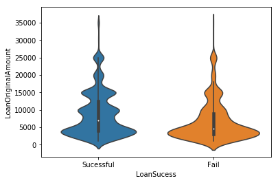

```python
sb.violinplot(data = random_samp, x = 'LoanSucess', y = 'LoanOriginalAmount');
```

## Correlation of BorrowerAPR and its strongest relationships

> We can see from this bar plot of BorrowerAPR's strongest relationships the various features that are most related to it. We can see the obvious ones like it being correlated with itself, as well as being strongly correlated with BorrowerRate (Which makes sense since the BorrowerRate is part of how the APR is calculated), but we also see some strange things like LenderYield and EstimatedReturn being quite high. Paradoxically, EstimatedLoss is also quite strongly correlated. We do see that the Prosper Rating is strongly negatively correlated so that if someone has a low Prosper Rating they will have a high APR, this makes sense as well since if someone has a lower Prosper Rating the Prosper system probably sees them as a risky loan option, thus they offset it with a high APR.

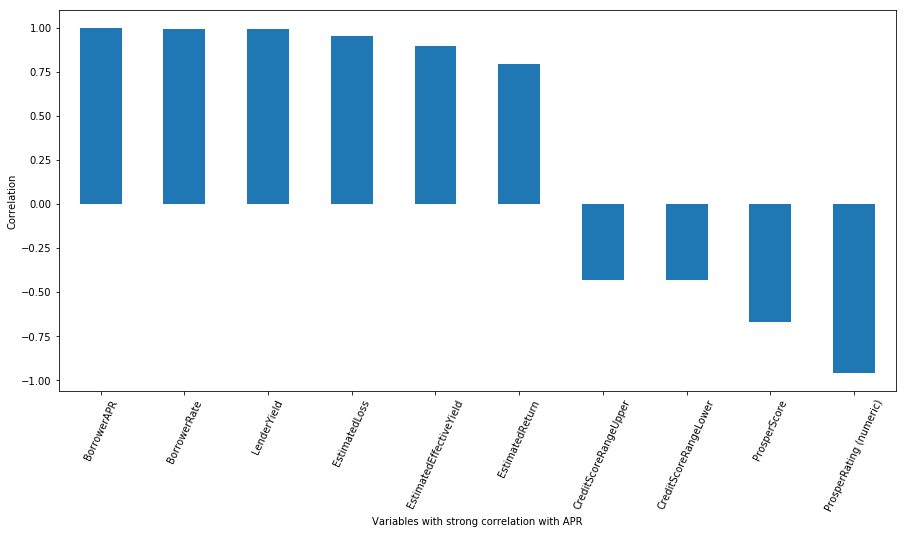

```python
plt.figure(figsize = [15, 7])
apr_corr_sorted.plot(kind='bar', color = base_color)
plt.xticks(rotation = 65);
plt.ylabel('Correlation')
plt.xlabel('Variables with strong correlation with APR');
```

## Interaction of BorrowerAPR, LoanAmount, and the Prosper Rating

> In order to take a closer look at the interaction of these three variables we will take a look at a scatter plot between BorrowerAPR and LoanOriginalAmount with Prosper Rating as a color encoding.

> We can see in the plot that when the Prosper Rating is low the APR is quite high, as well as the interesting feature of all the large dollar amount loans only being given to people who have decent Prosper Ratings and not to people with bad Prosper Ratings.

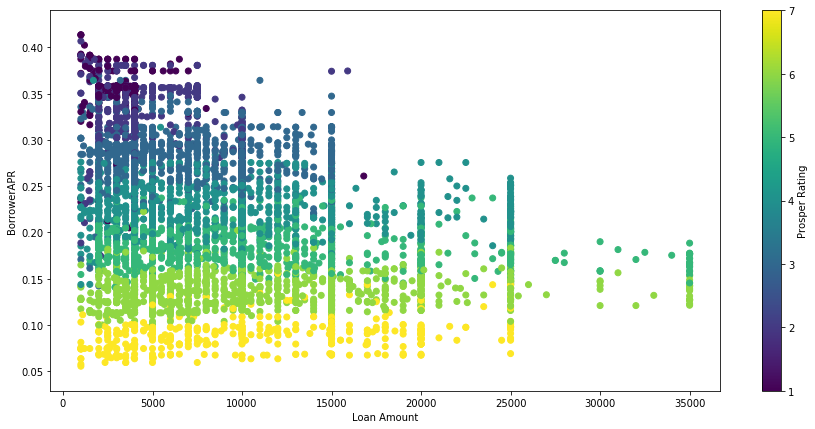

```python
plt.figure(figsize = [15, 7])
plt.scatter(data = random_samp, x = random_samp['LoanOriginalAmount'], y = random_samp['BorrowerAPR'], c = random_samp['ProsperRating (numeric)'])
plt.colorbar().set_label(label = 'Prosper Rating')
plt.ylabel('BorrowerAPR')
plt.xlabel('Loan Amount');
```